# Module 6 Report

Git In

10/18/2021

### Introduction

Humans are included in a class of organisms called endotherms, which are able to maintain their body temperature at a relatively constant level even when ambient temperatures are low. This was an important evolutionary development for mammals and fish since it allows for higher metabolic outputs (Ivanov 2005). Mammals also engage in some level of heterothermy where temperature can vary across the body (regionally) or over time (temporally) (Hetem et al. 2014). Heterothermy in endothermic species is used to modulate metabolic demands and reduce evaporative water loss (Ostrowski, Williams, and Ismael 2003), allowing for energy conservation mechanisms such as hibernation.

To allow for the storing of heat during the day and loss of heat at night, body temperature in mammals and many other animals varies in temporal self-sustaining oscillations typically dependent on the sleep cycle (Aschoff 1983). Because larger animals have a greater capacitance to store energy than smaller counterparts, it would follow that they require a smaller proportion of stored heat release to achieve water-loss savings. Therefore, it is expected that there will be a scaling relationship between the body temperature of humans with differing mass as well as among species with differing mass. However, some studies have shown that variations in Delta T across species is more closely related to environmental factors limiting water and energy supply as opposed to body mass. In a previous study, that the amplitude between the maximum body temperature and minimum body temperature in a 24 hour period was independent of body mass even when phylogeny was taken into account (Hetem et al. 2014).

This study aims to asses whether body mass affects the level of heterothermy as measured by the difference in the maximum and minimum body temperature in a daily oscillation. To investigate this, graphs of Delta T vs Mass were constructed in order to visualize the relationship between the variables.

Great intro!!

### Methods

Before constructing any models or graphs, the data was log-transformed in order to investigate the percentage changes seen in the data rather than the absolute differences. To investigate whether Delta T varied with mass, linear and allometric models were constructed both for the human data only, and for the combined human and mammal data. These models were compared by calculating AIC scores for them and comparing the AIC scores using AICw. The model with the lower AIC is a better predictor; however, if the difference is less than 4, the models are roughly equivalent. Graphs of Delta T vs Mass were also constructed in order to visually see the relationship between the variables.

What about the phylogenectic models?

### Results

Wow, that’s some nifty work with the loop.

But, we could have used the piping operations we learned about to get deltaT. You’re missing the importance of `pivot_wider()`.

```r
#dat3 to keep your naming convention
dat3 <- dat%>%
  group_by(subject,tod,mass)%>%
  na.omit()%>%
  filter(N>0.5*max(N))%>%
  summarize(m.temp=mean(Temp),n=n())%>%
  pivot_wider(names_from=tod,values_from = c(m.temp,n))%>%
  mutate(deltaT=abs(m.temp_day-m.temp_night))
```

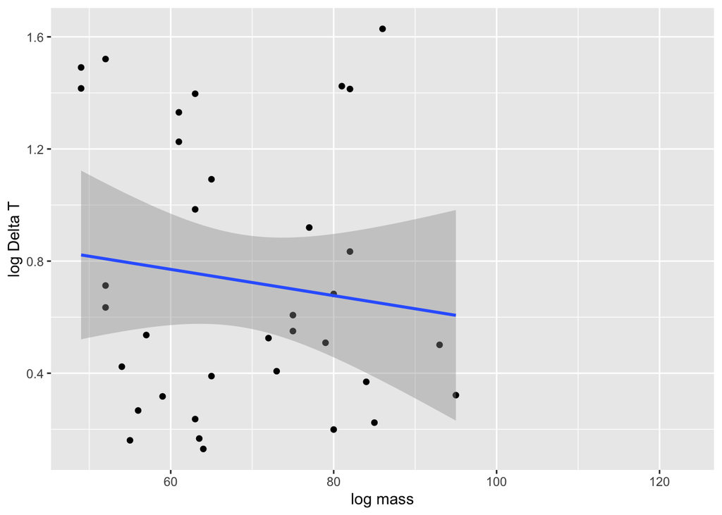

Plot of delta T vs mass for humans

A linear model of the human data was created as well as a least squares model to evaluate whether the data was isometric or allometric. An AIC was calculated for both models and AICw calculated to determine how the models compared. The AIC value for the allometric model was lower but the AIC scores were nearly equal.

Much of this paragraph above belongs in the methods.

```
##
## Call:
## lm(formula = temp_mean ~ mass, data = dat3)
##
## Residuals:
##      Min       1Q   Median       3Q      Max
## -0.17804 -0.06247  0.03681  0.07377  0.12465
##
## Coefficients:
##             Estimate Std. Error t value Pr(>|t|)
## (Intercept)  3.76820    0.22655  16.633   <2e-16 ***
## mass        -0.05508    0.05376  -1.025    0.309
## ---
## Signif. codes:  0 '***' 0.001 '**' 0.01 '*' 0.05 '.' 0.1 ' ' 1
##
## Residual standard error: 0.09281 on 69 degrees of freedom
##   (2 observations deleted due to missingness)
## Multiple R-squared:  0.01498,    Adjusted R-squared:  0.000709
## F-statistic:  1.05 on 1 and 69 DF,  p-value: 0.3092
```

```
##
## Formula: temp_mean ~ a * mass^b
##
## Parameters:
##   Estimate Std. Error t value Pr(>|t|)
## b -0.06797    0.06434  -1.056    0.294
## a  3.89894    0.36038  10.819   <2e-16 ***
## ---
## Signif. codes:  0 '***' 0.001 '**' 0.01 '*' 0.05 '.' 0.1 ' ' 1
##
## Residual standard error: 0.09277 on 69 degrees of freedom
##
## Number of iterations to convergence: 11
## Achieved convergence tolerance: 2.157e-08
##   (2 observations deleted due to missingness)
```

These model tables are ugly to print and they don’t have a caption. Try the `broom` package which tidys model output and use `kable`

```r
require(broom)
mass.lm%>%tidy%>%
  knitr::kable(caption="some informative caption")
```

some informative caption

| term | estimate | std.error | statistic | p.value |
| --- | --- | --- | --- | --- |
| (Intercept) | 3.7681978 | 0.2265501 | 16.63295 | 0.0000000 |
| mass | -0.0550798 | 0.0537610 | -1.02453 | 0.3091635 |

```
##         fit      delta         w
## 1 -131.7409 0.06401455 0.4919989
## 2 -131.8049 0.00000000 0.5080011
```

Again, I like the effort here to combine data, but it woulda been much easier with the pipe.

Using my dat3 to start….

```r
human.dat <- dat3%>%
  ungroup()%>%
  summarize(deltaT=mean(deltaT,na.rm = TRUE),mass=mean(mass*1000,na.rm = TRUE),species="Homo sapians",Order="Primata")%>%
  dplyr::select(Order,species,mass,deltaT)

dat_combined <- mammal%>%
  dplyr::select(Order,species,mass,deltaT)%>%
  add_row(human.dat)

#log transform dat_combined data
dat_combined_log <- dat_combined %>% mutate_at(c("mass","deltaT"),log)
```

We created a plot of combined human and mammal data of Delta T vs Mass which shows that for the combined data set, an increase in mass corresponds to a decrease in Delta T.

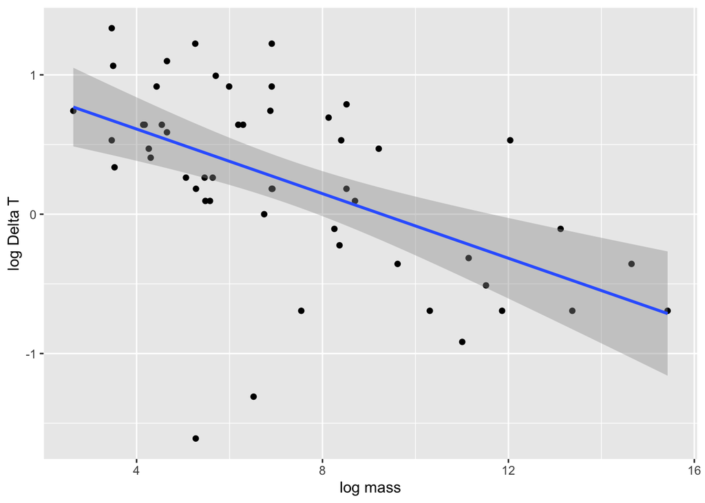

Combined Mammal and Human Delta T vs Mass

A linear model of the combined human and mammal data was created as well as a least squares model to evaluate whether the data was isometric or allometric. An AIC was calculated for both models and AICw calculated to determine how the models compared. The AIC value for the linear model was much lower so that is the better model and the data can be thought of as isometric.

```
##
## Call:
## lm(formula = deltaT ~ mass, data = dat_combined_log)
##
## Residuals:
##      Min       1Q   Median       3Q      Max
## -2.07302 -0.25816 -0.00354  0.40387  0.94977
##
## Coefficients:
##             Estimate Std. Error t value Pr(>|t|)
## (Intercept)  1.07471    0.19978   5.380 1.98e-06 ***
## mass        -0.11590    0.02539  -4.564 3.29e-05 ***
## ---
## Signif. codes:  0 '***' 0.001 '**' 0.01 '*' 0.05 '.' 0.1 ' ' 1
##
## Residual standard error: 0.5637 on 50 degrees of freedom
## Multiple R-squared:  0.2941, Adjusted R-squared:   0.28
## F-statistic: 20.83 on 1 and 50 DF,  p-value: 3.287e-05
```

```
##
## Formula: deltaT ~ a * mass^b
##
## Parameters:
##   Estimate Std. Error t value Pr(>|t|)
## b  -1.8699     0.7239  -2.583   0.0128 *
## a   7.5631     7.7484   0.976   0.3337
## ---
## Signif. codes:  0 '***' 0.001 '**' 0.01 '*' 0.05 '.' 0.1 ' ' 1
##
## Residual standard error: 0.6037 on 50 degrees of freedom
##
## Number of iterations to convergence: 25
## Achieved convergence tolerance: 9.713e-06
```

```
##        fit    delta          w
## 1 92.41737 0.000000 0.97234019
## 2 99.53682 7.119451 0.02765981
```

Again, we need a nice table with a caption. Use `kable`.

We created a plot of Delta T vs Mass by Taxonomic Group (Order) to evaluate if Order effectively predicted differences.

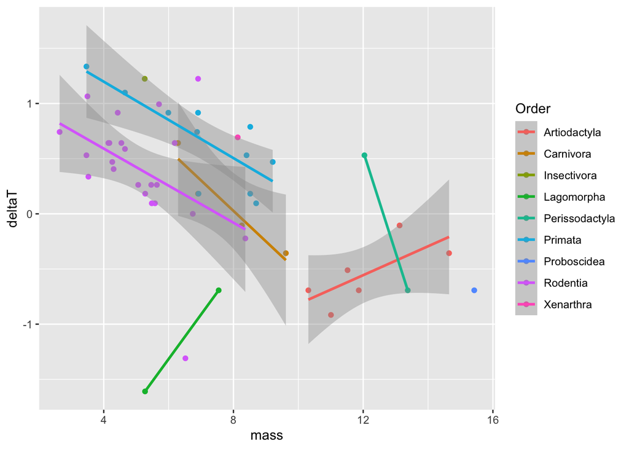

Delta T vs Mass by Order

We created a linear model that incorporated Order (lm(deltaT~mass*Order)) and performed an anova analysis on it. From the anova analysis, we can see that Order is a signficant predictor of the relationship between mass and Delta T (p = 5.224e-05 < 0.05). This means that taxonomic group with respect to order effectively predicts differences in the Delta T ~ Mass relationship across mammals.

```
## Analysis of Variance Table
##
## Response: deltaT
##            Df Sum Sq Mean Sq F value    Pr(>F)
## mass        1 6.3205  6.3205 39.9425 2.602e-07 ***
## Order       8 7.7988  0.9748  6.1605 5.224e-05 ***
## mass:Order  5 2.3834  0.4767  3.0124   0.02261 *
## Residuals  36 5.6967  0.1582
## ---
## Signif. codes:  0 '***' 0.001 '**' 0.01 '*' 0.05 '.' 0.1 ' ' 1
```

Although we can see that Order is a significant predictor of the Delta T ~ Mass relationship, we want to see if it actually fits the data better. To see this, we created two models, one with order taken into account and one without it, and ran an AIC analysis on both models. The one that took order into account had an AIC score more than ten points lower. Therefore, taking Order into account in the linear model results in a better model.

Well done using AIC in this context!

```
##        fit    delta           w
## 1 91.73378 10.79118 0.004516047
## 2 80.94260  0.00000 0.995483953
```

### Discussion

One of these factors can be phylogenetic information. When the mammals were grouped by order, anova analysis showed that order was a significant factor in predicting the Delta T to mass relationship since p = 5.224e-05 < 0.05. This means that there are more factors that effect Delta T in mammals than just mass. In further studies, factors such as climate and water supply of mammals could be investigated to further understand what predicts the level of heterothermy.

### Author Contributions

The introduction was written by Sarah Figueroa and Belinda Wang. Coding chunks and results were added by Steven LaFever and Emma Oss. Data collection and references were added by Belinda Wang. Methods were written by Steven LaFever. The discussion was written by Sarah Figueroa and Emma Oss.

### References

Aschoff, Jurgen. 1983. “Review: Circadian Control of Body Temperature.” *Journal of Thermal Biology* 8: 143–47.

Hetem, Robyn S., Shane K. Maloney, Andrea Fuller, and Duncan Mitchell. 2014. “Heterothermy in Large Mammals: Inevitable or Implemented?” *Biological Reviews* 91 (1): 187–205.

Ivanov, KP. 2005. “The Development of the Concepts of Homeothermy and Thermoregulation.” *Journal of Thermal Biology* 31: 24–29.

Ostrowski, Stéphane, Joseph B Williams, and Khairi Ismael. 2003. “Heterothermy and the Water Economy of Free-Living Arabian Oryx (Oryx Leucoryx).” *Journal of Experimental Biology* 206 (9): 1471–8.